# Padrón de beneficiarios de Academias

Jacob Aviña

2022-09-24

## Introducción

El SMDIF Centro cuenta con un programa de capacitación para el trabajo enfocado en la atención de población en condición de vulnerabilidad, mismo que busca formar y fortalecer las habilidades técnicas a través de una oferta de talleres de oficios en diferentes especialidades. Por lo que, para conocer a nuestra población beneficiaria analizaremos el padrón de alumnas y alumnos inscritos en estos talleres.

Algunos de los datos que se encuentran en esta base de datos son:

```
##  [1] "No"                  "Nombre"              "Especialidad"
##  [4] "Maestra"             "Domicilio"           "Trabaja actualmente"
##  [7] "Edad"                "Sexo"                "Población indígena"
## [10] "Estado Civil"        "Nuevo ingreso"       "N° de folio"
## [13] "Teléfono"
```

[interactive chart not shown]

### Estadísticas descriptivas

Empezaremos con una representación gráfica de una muestra de los datos correspondientes a la `Edad`, con los que podemos ver que el rango de edad de nuestra población atendida es amplio, es decir, actualmente atendemos niños desde 13 años de edad hasta adultos mayores de más de 60 años.

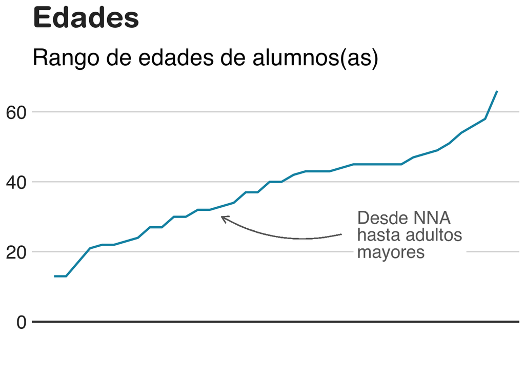

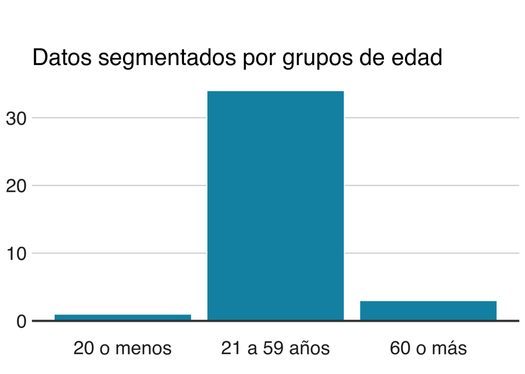

De igual manera, podemos hacer un conteo de nuestras alumnas y alumnos inscritos por `Sexo`:

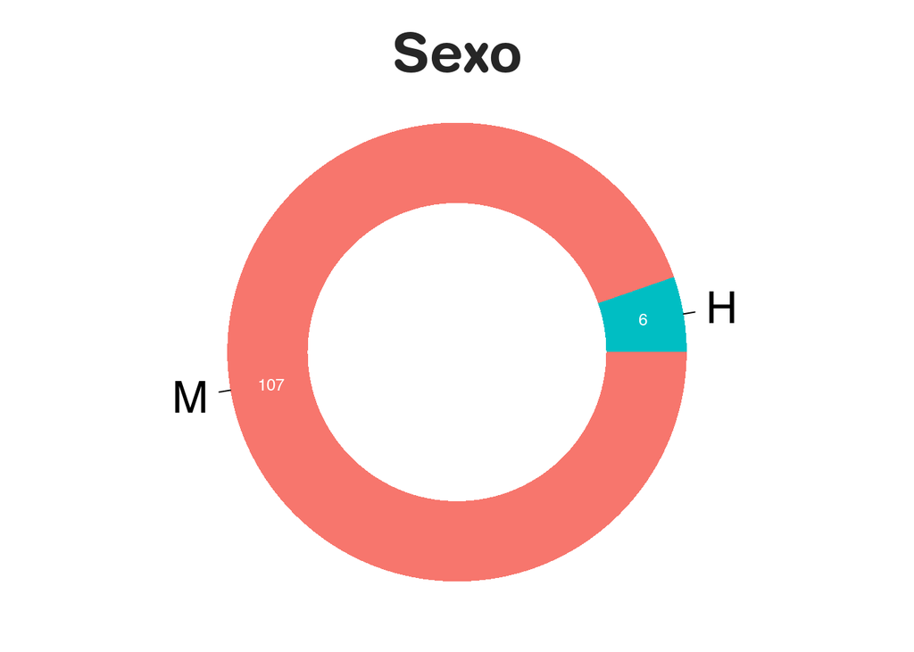

Para observar la proporción de qué taller cuenta con más inscritos haremos una visualización del número de alumnos inscritos por `Especialidad`:

| Especialidad | n | pct |
| --- | --- | --- |
| Bordado | 11 | 9.734513 |
| Corte y Confeccion | 48 | 42.477876 |
| Cultora De Belleza | 5 | 4.424779 |
| Manualidades | 8 | 7.079646 |
| Pintura Textil | 3 | 2.654867 |
| Reposteria | 20 | 17.699115 |
| Sastreria | 18 | 15.929203 |

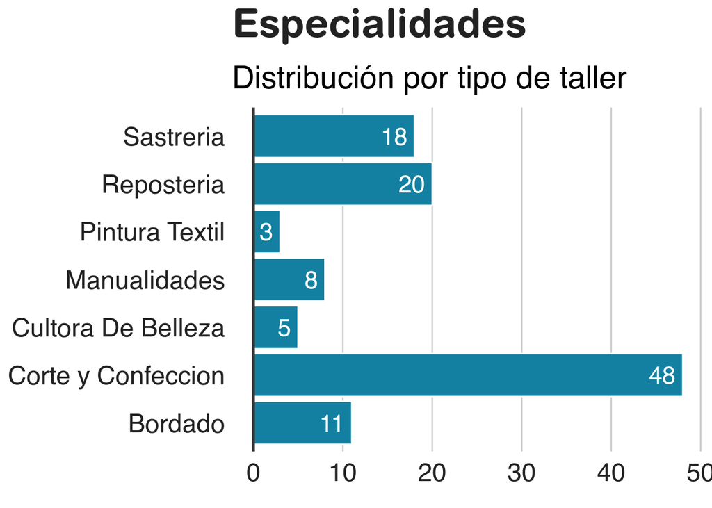

Haremos una representación visual de los datos de la columna `Trabaja actualmente (Sí/No)` para saber el porcentaje de población inscrita que se encuentra trabajando actualmente. Para ello, convertiremos la respuesta a una varibale booleana que cumpla la condición `TRUE` cuando la respuesta sea `SI`:

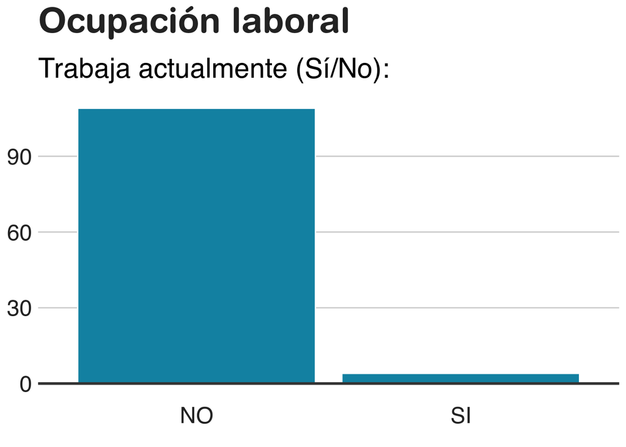

Un dato que obtenemos de nuestra población es el `Estado civil`:

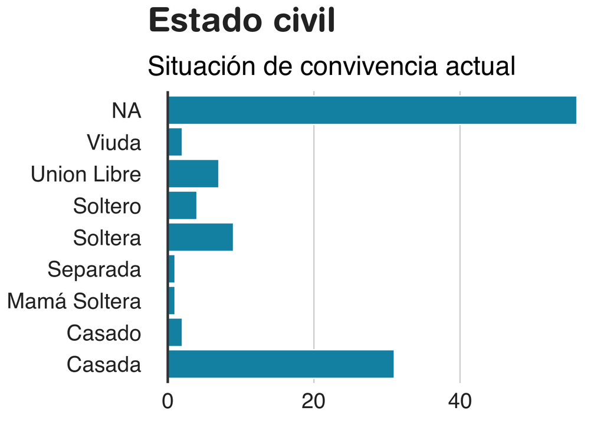